# Trabajo final

Yangyang Li

13/6/2019

# 1 Introducción

El objetivo del trabajo es buscar una firma genética que sirva para discriminar pacientes diagnosticados con tumor de próstata.  
Los tumores de próstata se encuentran entre los cánceres más heterogéneos, tanto histológicamente como clínicamente. El análisis de expresión de microarrays se utilizó para determinar si las diferencias biológicas globales subyacen a las características patológicas comunes del cáncer de próstata e identificar genes que podrían anticipar el comportamiento clínico de esta enfermedad. Si bien no se encontró una correlación de la expresión de la edad, se encontraron antígenos séricos específicos de la próstata (PSA) y medidas de invasión local, se identificó un conjunto de genes que se correlacionaron fuertemente con el estado de diferenciación tumoral según lo medido por la puntuación de Gleason. Además, un modelo que utiliza solo datos de expresión génica predijo con precisión el resultado del paciente después de la prostatectomía. Estos resultados apoyan la idea de que el comportamiento clínico del cáncer de próstata está vinculado a las diferencias subyacentes en la expresión de los genes que son detectables en el momento del diagnóstico.

# 2 Metodología

## 2.1 Datos

-136 muestras  
-Expresión génica: utilizando microarrays de oligonucleótidos que contienen sondas para 12,600 genes

## 2.2 Algoritmos de clasificación

-Filtro01: gain.ratio  
-Filtro02: symmetrical.uncertainty  
-Filtro03: chi.squared  
-Wrapper SFS

A partir de las variables seleccionadas con diferentes filtros, utilizaremos el método wrapper SFS (Stepwise Forward Seletion) para busacar la mejor combinación de variables para diferentes modelos (regresión logística, ANN, SVM y árboles de decisión). Se usará el área bajo la curva ROC como métrica de evaluación del rendimiento del modelo.  
Para la validación interna de todos los modelos usamos 10-fold cross-validation.

# 3 Procedimiento

## 3.1 Cargar datos

Data set completo: training data + test data

```r
data_train <-  read.arff("/Users/yangyangli/Downloads/ProstateCancer/prostate_tumorVSNormal_train.arff")
data_test <-  read.arff("/Users/yangyangli/Downloads/ProstateCancer/prostate_tumorVSNormal_test.arff")
data<- rbind(data_train,data_test)
```

## 3.2 Selección de variables

### 3.2.1 FSelector

En este apartado vamos filtrar 10 variables importantes utilizando 3 diferentes filters:

#### 3.2.1.1 gain.ratio

```r
weights_01 <- gain.ratio(Class~.,data)
subset_gainRatio <- cutoff.k(weights_01, 10)
```

#### 3.2.1.2 symmetrical.uncertainty

```r
weights_02 <- symmetrical.uncertainty(Class~.,data)
subset_sym <- cutoff.k(weights_02, 10)
```

#### 3.2.1.3 chi.squared

```r
weights_03 <- chi.squared(Class~.,data)
subset_chi <- cutoff.k(weights_03, 10)
```

```r
t <- rbind(subset_gainRatio,subset_sym,subset_chi)
t[,0:7]
```

```
##                  [,1]       [,2]       [,3]       [,4]       [,5]
## subset_gainRatio "37639_at" "37720_at" "41468_at" "37366_at" "36491_at"
## subset_sym       "37639_at" "41288_at" "39315_at" "35742_at" "37720_at"
## subset_chi       "41288_at" "39031_at" "39315_at" "36666_at" "35742_at"
##                  [,6]         [,7]
## subset_gainRatio "41288_at"   "31538_at"
## subset_sym       "41468_at"   "36666_at"
## subset_chi       "39243_s_at" "37639_at"
```

## 3.3 Stepwise Forward Selection

El clasificador de wrapper empaquetando algoritmos específicos de clasificación / regresión y usando algunos algoritmos de optimización, elige la mejor combinación de los atributos. Pero el tiempo de ejecución es elevado, especialmente cuando tenemos 12,600 genes en nuestro conjunto de datos, tomaría mucho tiempo en seleccionar la mejor combinacion de todas las combinaciones de genes posibles, por lo que en este trabajos usamos el algoritmo Stepwise Forward realiza la selección de variables entre las variables filtradas de arriba.

### 3.3.1 Funciones para ajuste de parámetros para regresión logística, nnet, svm, dt.

#### 3.3.1.1 ANN

```r
addq <- function(x) paste0("`", x, "`")
parameter.nnet <- function(d.train,d.test,variables){
   formula1 <- as.formula( paste("(Class=='Tumor')*1.0",paste(addq(variables),collapse = "+"),sep = "~") )
       m <- expand.grid(size=seq(1,6,by=1),decay=seq(0,6e-05,by=1e-05))
       auc <- vector()
       for (i in 1:dim(m)[1]) {
        set.seed(5)
        modelo <-  nnet(formula1,data=d.train,size=m$size[i],maxit=500, decay=m$decay[i],trace=FALSE)
        predict.test <- predict(modelo,d.test,type="raw")
        auc.test <- auc(d.test$Class,predict.test)[1]
        auc <- append(auc,auc.test)
       }
       m$auc <- auc
  return(m)
}
```

#### 3.3.1.2 SVM

```r
parameter.svm <- function(d.train,d.test,variables){
       m <- expand.grid(cost=seq(100,800,by=100),gamma=10^(-6:-1))
       formula1 <- as.formula( paste("(Class=='Tumor')*1.0",paste(addq(variables),collapse = "+"),sep = "~") )
      auc <- vector()
      for (i in 1:dim(m)[1]) {
        modelo <-  svm(formula1,data=d.train,cost=m$cost[i],gamma=m$gamma[i],probability=TRUE)
        predict.test <- predict(modelo,d.test,probability=TRUE)
        auc.test <- auc(d.test$Class,predict.test)[1]
        auc <- append(auc,auc.test)
      }
   m$auc <- auc
  return(m )
}
```

#### 3.3.1.3 DT

```r
parameter.dt <- function(d.train,d.test,variables){
      cp <- c(0.01,0.001,0.0001,0.00001)
      formula1 <- as.formula( paste("(Class=='Tumor')*1.0",paste(addq(variables),collapse = "+"),sep = "~") )
      auc <- vector()
      for (i in 1:4) {
        dt.fit <- rpart(formula1,data=d.train,control=rpart.control(cp=cp[i]))
        dt.pred <- predict(dt.fit,d.test)
        auc.test <- auc(d.test$Class,dt.pred)[1]
        auc <- append(auc,auc.test)
      }
      r <- cbind(cp,auc)
  return( as.data.frame(r) )
}
```

### 3.3.2 Función para calcular la métrica: AUC

```r
estimaMetrica <- function(d.train,d.test,variables,modelo,parameters){
  formula <- as.formula( paste("(Class=='Tumor')*1.0",paste(addq(variables),collapse = "+"),sep = "~") )
      if(modelo=="nnet"){
        modelo <- nnet(formula,data = d.train,size=parameters$size,maxit=1000,decay=parameters$decay,trace=FALSE)
        predict.test <- predict(modelo,d.test,type="raw")
        auc.test <- auc(d.test$Class,predict.test)
      }
      if(modelo=="svm"){
        modelo <-  svm(formula,data=d.train,size=parameters$cost,gamma=parameters$gamma,probability=TRUE)
        predict.test <- predict(modelo,d.test,probability=TRUE)
        auc.test <- auc(d.test$Class,predict.test)
      }
      if(modelo=="dt"){
        formula.dt <- as.formula(paste("Class",paste(addq(variables),collapse = "+"),sep = "~") )
        dt.fit <- rpart(formula.dt, data=d.train, control=rpart.control(cp=parameters$cp))
        dt.pred <- predict(dt.fit,d.test)[,"Tumor"]
        auc.test <- auc(d.test$Class,dt.pred)
      }
     if(modelo=="glm"){
        modelo <- glm(formula,data=d.train,family = binomial("logit"))
        predict.test <- predict(modelo,d.test,type="response")
        auc.test <- auc(d.test$Class,predict.test)
        }
      return(auc.test)
}
```

### 3.3.3 Eval function for wrapper

Implementación de **eval.fun** para el forward.search(attributes, eval.fun),se emplea 10-fold cross-validation para cada modelo:

```r
k_fold <- function(subset,type){
  folds <- createFolds(data$Class,k=10)
  df <- vector()
  for (i in 1:10) {
   d.test <- data[folds[[i]],c(subset,"Class")]
   d.train <- data[-folds[[i]],c(subset,"Class")]

     if(type == "nnet"){
       parameter <- parameter.nnet(d.train,d.test,subset)
       best.pt <- parameter[which.max(parameter$auc),]
       result <- estimaMetrica(d.train,d.test,subset,"nnet",best.pt)
       }
     if(type == "svm"){
       parameter <- parameter.svm(d.train,d.test,subset)
       best.pt <- parameter[which.max(parameter$auc),]
       result <- estimaMetrica(d.train,d.test,subset,"svm",best.pt)}
     if(type == "dt"){
       parameter <- parameter.dt(d.train,d.test,subset)
       best.pt <- parameter[which.max(parameter$auc),]
       result <- estimaMetrica(d.train,d.test,subset,"dt",best.pt)}
     if(type =="glm"){
       result <- estimaMetrica(d.train,d.test,subset,"glm","p")}

   df <- cbind(df,result)
  }
 return(df)
}
wraper.k_fold.nnet <- function(subset){
   m = k_fold(subset,"nnet")
   return(mean(m))
}

wraper.k_fold.svm <- function(subset){
 m = k_fold(subset,"svm")
   return(mean(m))
}

wraper.k_fold.dt <- function(subset){
 m = k_fold(subset,"dt")
   return(mean(m))
}
wraper.k_fold.glm <- function(subset){
 m = k_fold(subset,"glm")
   return(mean(m))
}
```

### 3.3.4 Resultados de forward.search(attributes, eval.fun)

#### 3.3.4.1 nnet

```r
subset.nnet01 <- forward.search(subset_gainRatio,wraper.k_fold.nnet)
subset.nnet02 <- forward.search(subset_sym,wraper.k_fold.nnet)
subset.nnet03 <- forward.search(subset_chi,wraper.k_fold.nnet)
```

#### 3.3.4.2 SVM

```r
subset.svm01 <- forward.search(subset_gainRatio,wraper.k_fold.svm)
subset.svm02 <- forward.search(subset_sym,wraper.k_fold.svm)
subset.svm03 <- forward.search(subset_chi,wraper.k_fold.svm)
```

#### 3.3.4.3 DT

```r
subset.dt01 <- forward.search(subset_gainRatio,wraper.k_fold.dt)
subset.dt02 <- forward.search(subset_sym,wraper.k_fold.dt)
subset.dt03 <- forward.search(subset_chi,wraper.k_fold.dt)
```

#### 3.3.4.4 glm

```r
subset.glm01 <- forward.search(subset_gainRatio,wraper.k_fold.glm)
subset.glm02 <- forward.search(subset_sym,wraper.k_fold.glm)
subset.glm03 <- forward.search(subset_chi,wraper.k_fold.glm)
```

#### 3.3.4.5 Visualización de resultados:

```r
nnet <-t(rbind(subset.nnet01,subset.nnet02,subset.nnet03))
rownames(nnet) <- c("nnet_v1","nnet_v2")
svm <- t(rbind(subset.svm01,subset.svm02,subset.svm03))
rownames(svm) <- c("svm_v1","svm_v2","svm_v3","svm_v4")
dt <- t(rbind(subset.dt01,subset.dt02,subset.dt03))
rownames(dt) <- c("dt_v1","dt_v2","dt_v3","dt_v4","dt_v5")
glm <-t(rbind(subset.glm01,subset.glm02,subset.glm03))
rownames(glm) <- c("glm_v1","glm_v2","glm_v3","glm_v4")
dt <- rbind(nnet,svm,dt,glm)
colnames(dt) <- c("gain.ratio","symmetrical.uncertainty","chi.squared")
dt <- as.data.frame(dt)
```

| variables | gain.ratio | symmetrical.uncertainty | chi.squared |
| --- | --- | --- | --- |
| nnet_v1 | 37639_at | 37639_at | 35742_at |
| nnet_v2 | 41288_at | 35742_at | 37639_at |
| svm_v1 | 37639_at | 37639_at | 36666_at |
| svm_v2 | 41468_at | 41288_at | 35742_at |
| svm_v3 | 37366_at | 41468_at | 37639_at |
| svm_v4 | 41288_at | 36666_at | 36666_at |
| dt_v1 | 37639_at | 37639_at | 41288_at |
| dt_v2 | 37720_at | 41468_at | 39031_at |
| dt_v3 | 41468_at | 36666_at | 36149_at |
| dt_v4 | 36491_at | 37366_at | 41288_at |
| dt_v5 | 39756_g_at | 39243_s_at | 39031_at |
| glm_v1 | 37639_at | 37639_at | 39315_at |
| glm_v2 | 36491_at | 41288_at | 37639_at |
| glm_v3 | 41288_at | 39315_at | 36149_at |
| glm_v4 | 39755_at | 39243_s_at | 39315_at |

# 4 Concusión

```r
auc.nnet01 <- k_fold(subset.nnet01,"nnet")
auc.nnet02 <-k_fold(subset.nnet02,"nnet")
auc.nnet03 <-k_fold(subset.nnet03,"nnet")

auc.svm01 <- k_fold(subset.svm01,"svm")
auc.svm02 <-k_fold(subset.svm02,"svm")
auc.svm03 <-k_fold(subset.svm03,"svm")

auc.dt01 <- k_fold(subset.dt01,"dt")
auc.dt02 <- k_fold(subset.dt02,"dt")
auc.dt03 <- k_fold(subset.dt03,"dt")

auc.glm01 <- k_fold(subset.glm01,"glm")
auc.glm02 <-k_fold(subset.glm02,"glm")
auc.glm03 <-k_fold(subset.glm03,"glm")
```

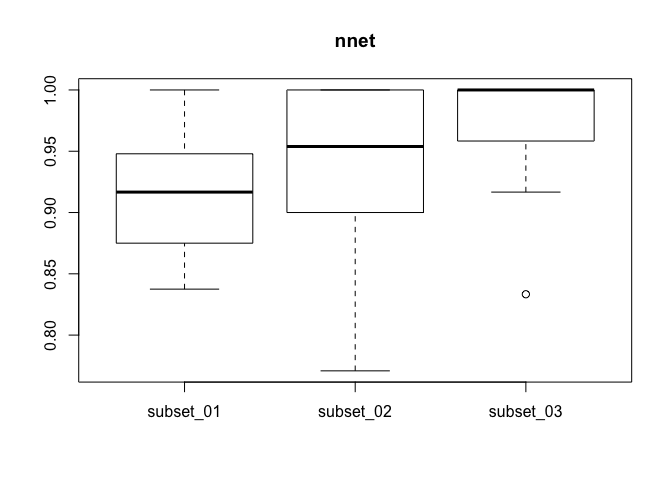

```r
flag <- factor(rep(c("subset_01","subset_02","subset_03"),each=10))

values_nnet <-c(auc.nnet01,auc.nnet02,auc.nnet03)
dataset_nnet <- as.data.frame(values_nnet,flag)

values_svm <-c(auc.svm01,auc.svm02,auc.svm03)
dataset_svm <- as.data.frame(values_svm,flag)

values_dt <-c(auc.dt01,auc.dt02,auc.dt03)
dataset_dt <- as.data.frame(values_dt,flag)

values_glm <-c(auc.glm01,auc.glm02,auc.glm03)
dataset_glm <- as.data.frame(values_glm,flag)

boxplot(values_nnet~flag, dataset_nnet,main="nnet")
```

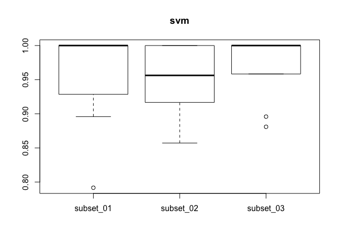

```r
boxplot(values_svm~flag, dataset_svm,main="svm")
```

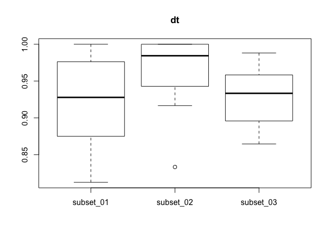

```r
boxplot(values_dt~flag, dataset_dt,main="dt")
```

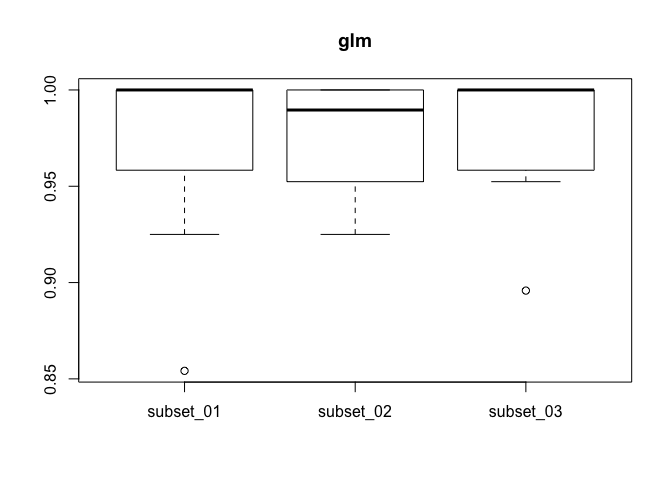

```r
boxplot(values_glm~flag, dataset_glm,main="glm")
```